# R Notebook

Assignment 2: Read in the restaurant level data: https://byuistats.github.io/M335/data/chipotle_reduced.csv

```r
library(tidyverse)
library(dplyr)
library(tidyr)
library(readr)
library("stringr")
library(ggplot2)
```

```r
data <- read_csv("/Users/enchiehyang/Documents/code/tutoring/homework_assignments/r_assignments/chipotle_reduced.csv")
```

```r
# this is a modification of function 1 which will return the day column and count
# for all stores not just 1 store
# the function takes no argument

function1 <- function(){
  data %>%
  select(region, placekey, popularity_by_day) %>%
  mutate(clean_popular = gsub("\\{|\\}", "", popularity_by_day)) %>%
  mutate(V2 = strsplit(as.character(clean_popular), ",")) %>%
  unnest(V2) %>%
  separate(V2, c("day", "count"), ":") %>%
  mutate(clean_day = gsub('"', '', day)) %>%
  mutate(count = as.numeric(count)) %>%
  select(region, placekey, clean_day, count)
}

base_output <- function1()
base_output
```

| region | placekey | clean_day | count |
| --- | --- | --- | --- |
| NY | 227-222@627-sd6-7dv | NA | NA |
| OK | zzw-223@5r8-fqv-xkf | Monday | 0 |
| OK | zzw-223@5r8-fqv-xkf | Tuesday | 0 |
| OK | zzw-223@5r8-fqv-xkf | Wednesday | 1 |
| OK | zzw-223@5r8-fqv-xkf | Thursday | 0 |
| OK | zzw-223@5r8-fqv-xkf | Friday | 0 |
| OK | zzw-223@5r8-fqv-xkf | Saturday | 1 |
| OK | zzw-223@5r8-fqv-xkf | Sunday | 0 |
| CA | 227-222@5z6-96f-btv | Monday | 20 |
| CA | 227-222@5z6-96f-btv | Tuesday | 22 |

[output cut: 990 more lines]

# part 1

```r
# we'll take the results of the above dataframe and take the most popular day for all restaurants
# then we'll group by the day and do a sum of all counts for that day

count_df <- base_output %>%
  filter(!is.na(clean_day)) %>%
  arrange(placekey, desc(count)) %>%
  group_by(placekey) %>%
  mutate(rank = rank(placekey, ties.method = "first")) %>%
  filter(rank==1) %>%
  select(clean_day) %>%
  group_by(clean_day) %>%
  summarise(n = n()) %>%
  arrange(desc(n))
count_df
```

| clean_day | n |
| --- | --- |
| Friday | 965 |
| Thursday | 704 |
| Saturday | 591 |
| Tuesday | 231 |
| Wednesday | 92 |
| Monday | 55 |
| Sunday | 25 |

create a bar graph of the counts by day

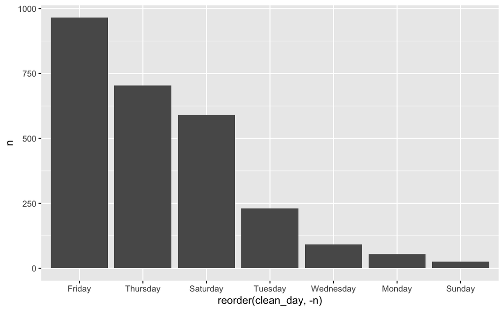

```r
# Basic barplot
ggplot(data=count_df, aes(x=reorder(clean_day, -n), y=n)) +
  geom_bar(stat="identity")
```

# part 2

Use Function 1 from the previous assignment to combine the popularity_by_day data across all restaurants. Then visualize the frequency distribution of visits by day of the week regardless of restaurant. This visualization should be done overall and another chart that facets by region.

Note that the unit of observation in this plot/analysis is an individual visit. In other words, we are counting how may individual visits occurred.

```r
# stores <- c("zzw-222@5vg-nwf-mp9", "22c-222@5z5-3rs-hwk", "zzw-223@5r8-fqv-xkf")
# filter(placekey %in% stores) %>%

combined_all_agg <- base_output %>%
  filter(!is.na(clean_day)) %>%
  arrange(placekey, desc(count)) %>%
  group_by(clean_day) %>%
  summarise(Frequency = sum(count))

combined_all_agg
```

| clean_day | Frequency |
| --- | --- |
| Friday | 195051 |
| Monday | 135699 |
| Saturday | 179489 |
| Sunday | 116884 |
| Thursday | 183473 |
| Tuesday | 157334 |
| Wednesday | 143778 |

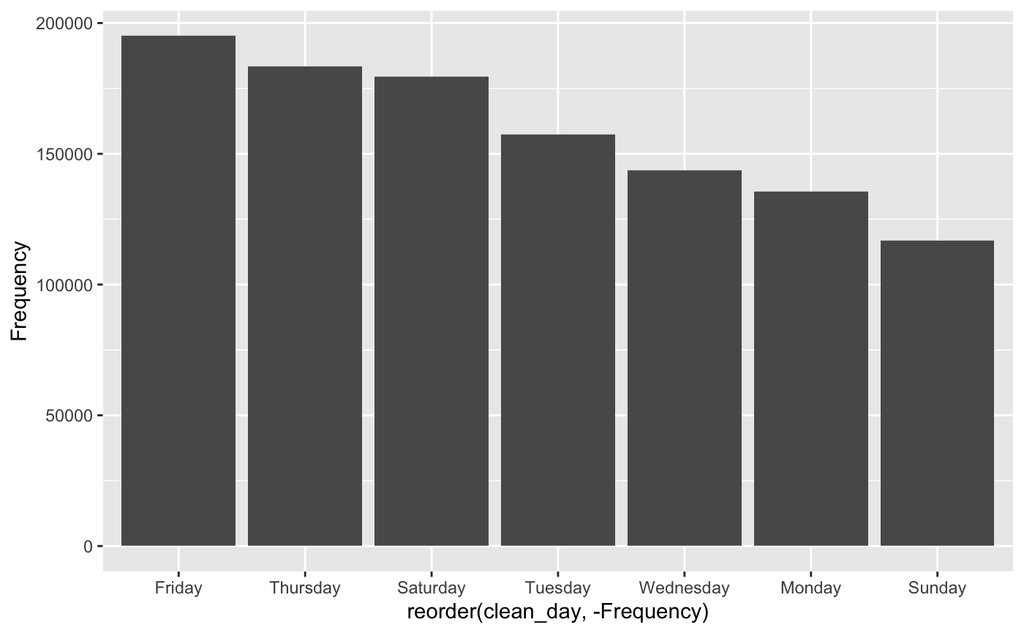

```r
# Basic barplot
ggplot(data=combined_all_agg, aes(x=reorder(clean_day, -Frequency), y=Frequency)) +
  geom_bar(position = "dodge", stat="identity")
```

let’s do the same as above but this time include region

```r
combined_all_agg <- base_output %>%
  filter(!is.na(clean_day)) %>%
  arrange(placekey, desc(count)) %>%
  group_by(region, clean_day) %>%
  summarise(Frequency = sum(count))
combined_all_agg
```

| region | clean_day | Frequency |
| --- | --- | --- |
| AL | Friday | 2041 |
| AL | Monday | 1296 |
| AL | Saturday | 1934 |
| AL | Sunday | 1151 |
| AL | Thursday | 1717 |
| AL | Tuesday | 1506 |
| AL | Wednesday | 1302 |
| AR | Friday | 588 |
| AR | Monday | 408 |
| AR | Saturday | 586 |

[output cut: 333 more lines]

create graph of count by region

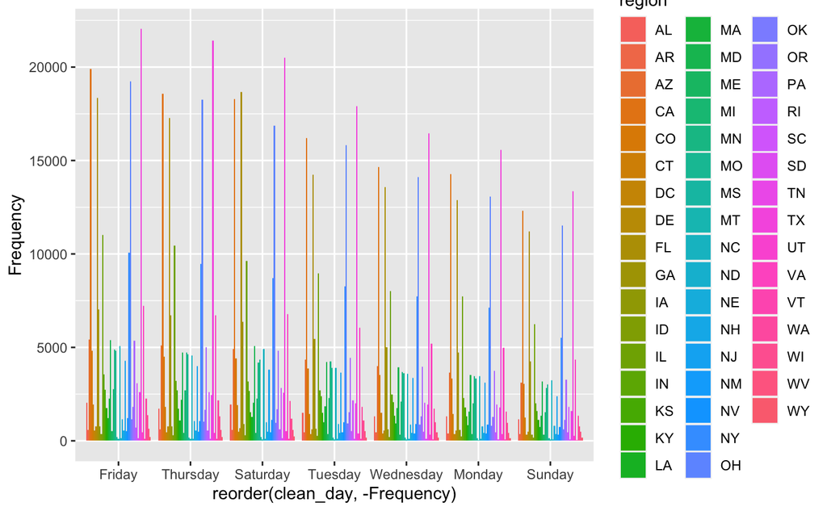

```r
# Basic barplot
ggplot(data=combined_all_agg, aes(x=reorder(clean_day, -Frequency), y=Frequency, fill=region)) +
  geom_bar(position = "dodge", stat="identity")
```